# Activity Monitoring Analysis - Course Project 1

Ajoy Kumar Palanivelu

October 8, 2017

## Importing Data

The code chunk below attempts to import data from a fileset downloaded. ‘activity’ is the name of dataset which has the imported data set. We are using colClasses to coerce the data into approproate columns in the imported Dataset

```r
activity <- read.csv(file = "activity.csv",header = TRUE,colClasses = c("integer","Date","integer"))
```

## What is mean total number of steps taken per day?

### Question 1: Calculate the total number of steps taken per day

### Steps taken per day

```r
library(tidyverse)

gact <- activity %>% group_by(date)

stp <- gact %>% summarize(stepsperday = sum(steps, na.rm = TRUE))

stp
```

```
## # A tibble: 61 x 2
##          date stepsperday
##        <date>       <int>
##  1 2012-10-01           0
##  2 2012-10-02         126
##  3 2012-10-03       11352
##  4 2012-10-04       12116
##  5 2012-10-05       13294
##  6 2012-10-06       15420
##  7 2012-10-07       11015
##  8 2012-10-08           0
##  9 2012-10-09       12811
## 10 2012-10-10        9900
## # ... with 51 more rows
```

### Total number of steps across the two months

```r
sum(stp$stepsperday)
```

```
## [1] 570608
```

### Question 2: If you do not understand the difference between a histogram and a barplot, research the difference between them. Make a histogram of the total number of steps taken each day

Histograms plot quantitative data with ranges of the data grouped into bins or intervals while bar charts plot categorical data

A Barplot is made up of a datacolumn plotted on the graph without any grouping / binning.

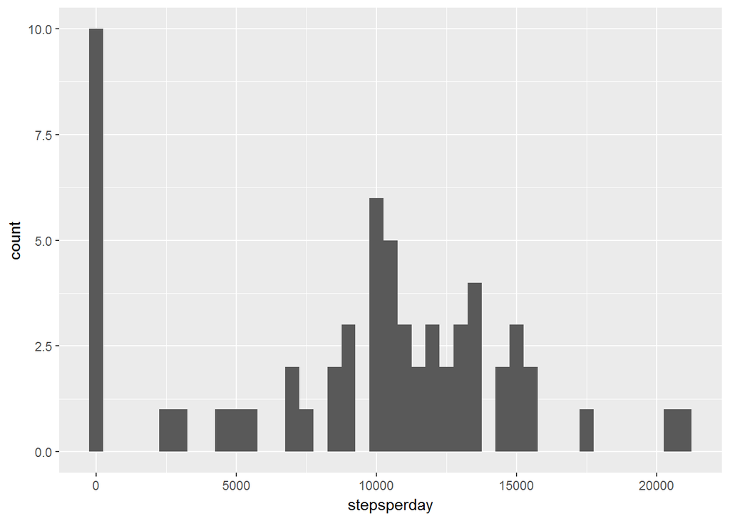

```r
ggplot(data = stp, aes(x = stepsperday)) + geom_histogram(binwidth = 500)
```

To calculate the mean and median number of steps taken per day we use the summarize function

```r
stp <- gact %>% summarize(Total_Steps = sum(steps,na.rm = TRUE))

sprintf("Total Number of Steps taken: %d", round(sum(stp$Total_Steps,na.rm = TRUE),0))
```

```
## [1] "Total Number of Steps taken: 570608"
```

```r
sprintf("Mean Value of Steps taken per day %d", round(mean(stp$Total_Steps,na.rm = TRUE),0))
```

```
## [1] "Mean Value of Steps taken per day 9354"
```

```r
sprintf("Median Value of Steps taken per day %d", round(median(stp$Total_Steps, na.rm = TRUE),0))
```

```
## [1] "Median Value of Steps taken per day 10395"
```

## What is the average daily activity pattern?

### Question 1: Make a time series plot (i.e. type = “l”) of the 5-minute interval (x-axis) and the average number of steps taken, averaged across all days (y-axis)

First, let’s group the dataset by 5 minute interval as noted by column ‘interval’ and find the average steps taken by interval

```r
iact <- activity %>% group_by(interval)

tsp <- iact %>% summarize(Step_Taken = mean(steps, na.rm = TRUE))
```

Then lets plot a time series graph showing different Interval values and average of steps per interval

After that lets find the maximum value in the timeseries plot using which.max function

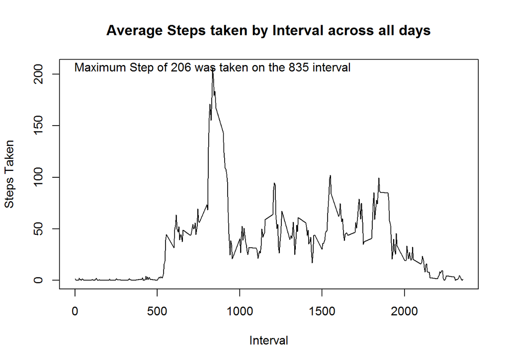

```r
plot(x = tsp$interval, y = tsp$Step_Taken, type = "l",main = "Average Steps taken by Interval across all days", xlab = "Interval", ylab = "Steps Taken")

ind <- which.max(tsp$Step_Taken)

la <- paste("Maximum Step of",round(tsp$Step_Taken[ind],digits = 0), "was taken on the", tsp$interval[ind],"interval")

text(x = tsp$interval[ind], y = tsp$Step_Taken[ind],labels = la)
```

```r
sprintf(la)
```

```
## [1] "Maximum Step of 206 was taken on the 835 interval"
```

## Imputing missing values

### Question1: Calculate and report the total number of missing values in the dataset (i.e. the total number of rows with NA’s

To find the number of rows with NA, we can use is.na option

```r
sum(is.na(activity$steps))
```

```
## [1] 2304
```

```r
sum(is.na(activity$date))
```

```
## [1] 0
```

```r
sum(is.na(activity$interval))
```

```
## [1] 0
```

Only Steps column have missing values

### Question2:Devise a strategy for filling in all of the missing values in the dataset. The strategy does not need to be sophisticated. For example, you could use the mean/median for that day, or the mean for that 5-minute interval, etc.

### Question3: Create a new dataset

First lets create a new data set

```r
nactivity <- activity
```

We already have an indexed table called tsp. tsp has the mean value for each interval. Our strategy is to use this indexed table to fill missing steps for each row with the appropriate mean value of the interval to which the row belongs to.

```r
sum(is.na(nactivity))
```

```
## [1] 2304
```

```r
for (i in 1:nrow(nactivity))
  {
  if(is.na(nactivity$steps[i]))
    {
    nactivity$steps[i] <- tsp$Step_Taken[tsp$interval ==  nactivity$interval[i]]
    }
}

sum(is.na(nactivity))
```

```
## [1] 0
```

### Question4: Make a histogram of the total number of steps taken each day and Calculate and report the mean and median total number of steps taken per day. Do these values differ from the estimates from the first part of the assignment? What is the impact of imputing missing data on the estimates of the total daily number of steps? *

First lets group the new data set by days. Then lets use summarize function to find the mean and median. Finally we can compare this against the original activity data set

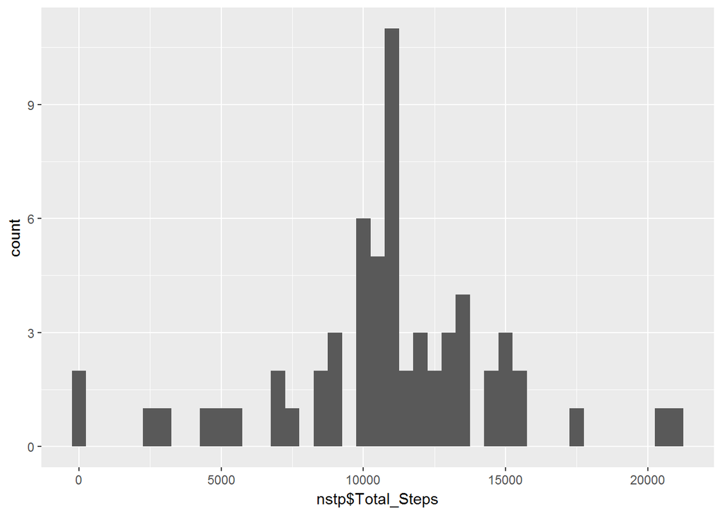

```r
nactivity <- group_by(nactivity, date)


nstp <- nactivity %>% summarize(Total_Steps = sum(steps, na.rm = TRUE))

ggplot(data = nstp,mapping = aes(nstp$Total_Steps)) +geom_histogram(binwidth = 500)
```

To compare the two different data sets we are using the summary option

```r
summary(stp)
```

```
##       date             Total_Steps
##  Min.   :2012-10-01   Min.   :    0
##  1st Qu.:2012-10-16   1st Qu.: 6778
##  Median :2012-10-31   Median :10395
##  Mean   :2012-10-31   Mean   : 9354
##  3rd Qu.:2012-11-15   3rd Qu.:12811
##  Max.   :2012-11-30   Max.   :21194
```

```r
summary(nstp)
```

```
##       date             Total_Steps
##  Min.   :2012-10-01   Min.   :   41
##  1st Qu.:2012-10-16   1st Qu.: 9819
##  Median :2012-10-31   Median :10766
##  Mean   :2012-10-31   Mean   :10766
##  3rd Qu.:2012-11-15   3rd Qu.:12811
##  Max.   :2012-11-30   Max.   :21194
```

### While the maximum values remain as is, we are seeing changes in minimum value, a shift in the mean as well as median because of imputing new values

## Are there differences in activity patterns between weekdays and weekends?

Lets introduce a column to specify if it is a weekday or weekend using ifelse function

```r
nactivity$weekday <- ifelse(weekdays(nactivity$date) %in% c("Saturday","Sunday"),"Weekend","Weekday")

nactivity$weekday <- as.factor(nactivity$weekday)
```

Now we are grouping the nactivity by weekday and Interval. Also we create a new dataset called wstp to store the summarize average values

```r
nactivity <- nactivity %>% group_by(interval, weekday)
wstp <- nactivity %>% summarize(AverageSteps = mean(steps,na.rm = TRUE))
```

Post grouping we are using lattice plotting to do a multi panel plotting of variables

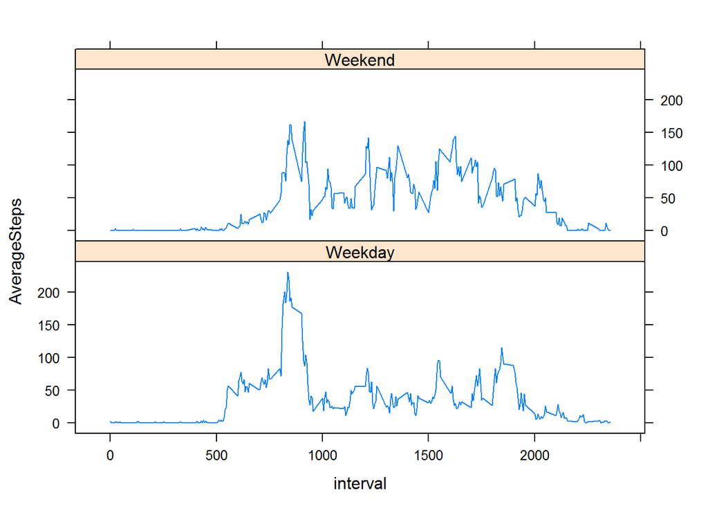

```r
library(lattice)
xyplot(AverageSteps~interval|weekday, data = wstp, type = "l",layout = c(1,2))
```